# Relación entre emociones líricas y métricas musicales en canciones de las últimas 5 décadas

Author

Ágatha Del Olmo Tirado

Published

December 4, 2025

# Introducción

La música es un fenómeno cultural y emocional que ha acompañado al ser humano a lo largo de la historia capaz de evocar todo tipo de sentimientos. Este trabajo se centra en analizar la relación entre las emociones expresadas en las letras de canciones y sus características musicales, con el objetivo de entender cómo ciertos elementos musicales pueden influir en la percepción emocional de los oyentes.

Para ello, se seleccionó un conjunto de canciones de los últimos 50 años, de manera que se pueda observar la evolución de las emociones y tendencias musicales a lo largo del tiempo. La información extraída incluye tanto las métricas musicales como las letras. Aunque el análisis temporal abarca cinco décadas, para la comparación directa con las métricas musicales se toma como referencia un subconjunto de los últimos cinco años, con el fin de evitar problemas computacionales.

A partir de las letras se realizó un análisis de sentimiento utilizando herramientas de procesamiento de lenguaje natural, permitiendo cuantificar emociones positivas y negativas en cada canción. El estudio combina así datos musicales objetivos con información emocional derivada de las letras, explorando posibles correlaciones entre la estructura musical y la carga emocional percibida.

# 1. Obtención y limpieza de los datos

## 1.1. Base de datos de canciones

Primero, se obtiene una base de datos desde Kaggle con información sobre las canciones más exitosas en Estados Unidos desde 1958 hasta 2024 gracias a la famosa clasificación “Billboard Hot 100”.

```r
top100 <- read_csv("./hot-100-current.csv")

head(top100)
```

```
# A tibble: 6 × 7
  chart_week current_week title        performer last_week peak_pos wks_on_chart
  <date>            <dbl> <chr>        <chr>         <dbl>    <dbl>        <dbl>
1 2022-01-01            1 All I Want … Mariah C…         1        1           50
2 2022-01-01            2 Rockin' Aro… Brenda L…         2        2           44
3 2022-01-01            3 Jingle Bell… Bobby He…         4        3           41
4 2022-01-01            4 A Holly Jol… Burl Ives         5        4           25
5 2022-01-01            5 Easy On Me   Adele             3        1           11
6 2022-01-01            6 It's The Mo… Andy Wil…         7        5           26
```

Como se puede observar, la base de datos incluye varias columnas relevantes para todos los meses de cada año:

- **chart_week**: semana de la clasificación
- **title**: nombre de la canción
- **performer**: autor/es de la canción
- **peak_pos**: la posición más alta en la que se ha encontrado
- **wks_on_chart**: total número de veces que ha aparecido la canción en el Billboard

Para poder trabajar con estos datos, se transforma la variable **chart_week** a tipo fecha, de la cual se extrae el año y el mes.

```r
top100_clean <- top100 %>%
  mutate(chart_week = as.Date(chart_week),
         month = month(chart_week),
         year = year(chart_week)) %>%
  arrange(chart_week)

head(top100_clean, 1)
```

```
# A tibble: 1 × 9
  chart_week current_week title  performer last_week peak_pos wks_on_chart month
  <date>            <dbl> <chr>  <chr>         <dbl>    <dbl>        <dbl> <dbl>
1 1958-08-04            1 Poor … Ricky Ne…        NA        1            1     8
# ℹ 1 more variable: year <dbl>
```

```r
tail(top100_clean, 1)
```

```
# A tibble: 1 × 9
  chart_week current_week title  performer last_week peak_pos wks_on_chart month
  <date>            <dbl> <chr>  <chr>         <dbl>    <dbl>        <dbl> <dbl>
1 2024-06-08          100 Tu Na… Fuerza R…         0       66           13     6
# ℹ 1 more variable: year <dbl>
```

Con el año de cada canción, se filtra la base de datos para que extraiga solo los últimos 50 años (desde 1975 hasta 2024). Entonces, se reduce la cantidad de canciones a 5 por año, seleccionando la posición más alta (**peak_pos**) y luego desempatando por la que más semanas haya pasado en el ránking (**wks_on_chart**), eliminando las canciones que puedan salir duplicadas (si ha sido top 100 en varios meses de un año).

```r
top100_clean <- top100_clean %>%
  filter(year >= 1975) %>%
  group_by(year) %>%
  arrange(peak_pos, desc(wks_on_chart)) %>%
  distinct(title, .keep_all = TRUE) %>%
  slice_head(n = 5) %>%
  ungroup() %>%
  mutate(id = row_number())
```

Por último, se crea la variable **song**, que combina el título y el nombre del artista separado por una coma. Este *dataframe* llamado **songs_df** es el que se utilizará en adelante.

```r
songs_df <- top100_clean %>%
  mutate(song = paste0(title, ", ", performer)) %>%
  select(id, song)

head(songs_df)
```

```
# A tibble: 6 × 2
     id song
  <int> <chr>
1     1 My Eyes Adored You, Frankie Valli
2     2 Love Will Keep Us Together, The Captain & Tennille
3     3 Rhinestone Cowboy, Glen Campbell
4     4 Before The Next Teardrop Falls, Freddy Fender
5     5 Philadelphia Freedom, The Elton John Band
6     6 Venus, Frankie Avalon
```

## 1.2. Letras de las canciones

Con el nombre de las canciones más exitosas de cada uno de los últimos cincuenta años, se procede a realizar un scraping dinámico con el que se obtienen las letras de las canciones.

Para ello se utiliza RSelenium, una herramienta que permite automatizar navegadores web, interactuar con la página y extraer información.

Se utiliza un rsDriver para abrir una sesión en el navegador, eligiendo la versión más reciente del driver de Firefox y asignando un puerto aleatorio para evitar conflictos. La variable driver contiene el cliente de RSelenium, que permite interactuar con la página web, navegar y extraer los datos necesarios.

```r
songs <- songs_df$song

rD <- rsDriver(browser = "firefox",
               geckover = "latest",
               iedrver = NULL,
               chromever = NULL,
               phantomver = NULL,
               extraCapabilities = eCaps,
               port = as.integer(runif(1, 4000, 8000))
)

driver <- rD[["client"]]
```

Se navega a *Genius*, que es una página web con las letras de miles de canciones que permite que los usuarios aporten anotaciones e interpretaciones a las letras de canciones. Se aceptan las cookies, y se crea un *dataframe* que se va a ir rellenando con un bucle que extraerá el *html* de la página pasándole como parámetro el nombre de la canción.

**A tener en cuenta…**

Todo código que incluye el uso de scraping dinámico se ha dejado como no ejecutable por temas de rendimiento a la hora de renderizar el documento; para poder asegurar la reproducibilidad de los datos, se han guardado todas las tablas relevantes en formato .xlsx para poder cargarlas cuando sean necesarias.

```r
driver$navigate("https://genius.com/Rick-astley-never-gonna-give-you-up-lyrics")

Sys.sleep(0.5)

cookie_button <- driver$findElement(
  using = "xpath",
  value = '//*[@id="onetrust-accept-btn-handler"]'
)
cookie_button$clickElement()

Sys.sleep(0.5)

lyrics_vec <- c()

html_df <- data.frame(
  song = character(),
  html = character(),
  stringsAsFactors = FALSE
)

for (song in songs){

  html_raw <- tryCatch({

    input_box <- driver$findElement(using = "xpath",
                                    value = '/html/body/div[1]/nav/div[2]/form/input')
    input_box$clearElement()
    input_box$sendKeysToElement(list(song, key = "enter"))

    Sys.sleep(5)

    top_song_button <- driver$findElement(
      using = "xpath",
      value = '/html/body/routable-page/ng-outlet/search-results-page/div/div[2]/div[1]/div[2]/search-result-section/div/div[2]/search-result-items/div/search-result-item/div/mini-song-card/a/div[2]/div[1]/div[1]'
    )
    top_song_button$clickElement()

    Sys.sleep(3)

    driver$getPageSource()[[1]]

  }, error = function(e) {

    driver$navigate("https://genius.com/Rick-astley-never-gonna-give-you-up-lyrics")

    return(NA)
  })

  html_df <- rbind(html_df,
                   data.frame(song = song,
                              html = html_raw,
                              stringsAsFactors = FALSE))
}

driver$close(); rD$server$stop()
```

De los *htmls* se pretende extraer la letra, pero aquí hay un detalle esencial a tener en cuenta: en las páginas de *Genius*, la letra de una canción no aparece en un único bloque, sino dividida en varios nodos dentro de `data-lyrics-container="true"`. Esto ocurre porque Genius usa dos tipos de estructuras: unas partes de la letra que permiten anotaciones y comentarios se representan con *html* más complejo, mientras que las partes sin anotaciones se muestran simplemente como texto.

Esta mezcla hace que la letra esté fragmentada en diferentes nodos de distintos tipos, por lo que se debe extraer por completo el “contendedor” y unificar ambos tipos para reconstruir la letra completa. El problema de este método es que el contenedor incluye las etiquetas y texto que no interesa, por eso se eliminan con la función `str_replace_all`.

```r
html_df <- read.xlsx("html_df.xlsx")

lyrics_df <- html_df %>%
  mutate(
    lyrics = map_chr(html, function(raw_html) {

      if (is.na(raw_html) || raw_html == "") return(NA_character_)

      page <- read_html(raw_html)

      nodes <- page %>%
        html_elements(xpath = '//*[@id="lyrics-root"]//div[@data-lyrics-container="true"]')

      if (length(nodes) == 0) return(NA_character_)

      text <- nodes %>%
        map_chr(as.character) %>%
        str_replace_all("<br ?/?>", "\n") %>%
        str_replace_all("<.*?>", "") %>%
        str_replace_all("\\[.*?\\]", "") %>%
        str_replace_all("\\*.*?\\*", "") %>%
        str_replace_all("&nbsp;", " ")

      paste(text, collapse = "\n\n")
    })
  )
```

Tras extraer las letras, se comrpueba que algunas canciones no tienen contenido. Algunos casos tienen sentido porque se tratan de canciones instrumentales, como *A Fifth Of Beethoven*. Sin embargo, en otros casos la ausencia de letra se debía a que el título no coincidía con ninguna entrada en Genius y, por lo tanto, no pudo extraer su html.

```r
lyrics_df %>% filter(is.na(lyrics)) %>% select(song)
```

```
                                                                           song
1                            Love Will Keep Us Together, The Captain & Tennille
2                                     Philadelphia Freedom, The Elton John Band
3                      A Fifth Of Beethoven, Walter Murphy & The Big Apple Band
4                                       (Love Is) Thicker Than Water, Andy Gibb
5                                           Chariots Of Fire - Titles, Vangelis
6                       Baby, Come To Me, Patti Austin A Duet With James Ingram
7                    Islands In The Stream, Kenny Rogers Duet With Dolly Parton
8                          (Can't Live Without Your) Love And Affection, Nelson
9                               You're Makin' Me High/Let It Flow, Toni Braxton
10 Candle In The Wind 1997/Something About The Way You Look Tonight, Elton John
11                           Shake Ya Tailfeather, Nelly, P. Diddy & Murphy Lee
12                           Shake Ya Tailfeather, Nelly, P. Diddy & Murphy Lee
13                                         I Gotta Feeling, The Black Eyed Peas
14                Give Me Everything, Pitbull Featuring Ne-Yo, Afrojack & Nayer
15                                              Call Me Maybe, Carly Rae Jepsen
16                  Can't Hold Us, Macklemore & Ryan Lewis Featuring Ray Dalton
17                                          Stay, The Kid LAROI & Justin Bieber
```

```r
ids_na <- lyrics_df %>% mutate(id = row_number()) %>% filter(is.na(lyrics)) %>% pull(id)

songs_na <- readLines("./songs_na.txt", encoding = "UTF-8")

full_txt <- paste(songs_na, collapse = "\n")

chunks <- str_split(full_txt, pattern = "(?=SONG \\d+)", simplify = TRUE)[2:18]

chunks_clean <- chunks %>%
  str_replace("^SONG \\d+\\s*", "") %>%
  str_trim()
```

Se puede ir rellenando el objeto **lyrics_df_full** usando el identificador de las filas que tenían un *NA*. De esta forma, ya no hay ninguna canción sin letra.

```r
lyrics_df_full <- lyrics_df
count = 1

for (chunk in chunks_clean){

  lyrics_df_full$lyrics[ids_na[count]] <- chunk

  count <- count + 1
}

lyrics_df_full %>% filter(is.na(lyrics))
```

```
[1] song   html   lyrics
<0 rows> (or 0-length row.names)
```

A continuación, se limpia el texto para eliminar todo aquello que pueda ser ruido para el análisis. En muchos casos, el “contenedor” mencionado previamente incluía una introducción sobre la canción al inicio que acababa en “Read More” con un botón para desplegar más información, de forma que todo lo que viniera antes de estas palabras (incluidas estas) se elimina. Además, algunas tenían palabras como Contributors (y el número de personas que han añadido una anotación en la letra), Billboard o Music Video, que no eran más que etiquetas de la página *Genius.* Estos patrones de texto serían muy difíciles de encontrar en una letra de canción, por eso se pueden eliminar sin preocupación.

```r
top_100_lyrics <- lyrics_df_full %>%
  mutate(lyrics = gsub("\\b\\d+ Contributors.*?Lyrics", "", lyrics),
         lyrics = ifelse(lyrics == "NA", NA, lyrics))

top_100_lyrics$lyrics <- sapply(top_100_lyrics$lyrics, function(text) {
  text <- sub(".*Read More", "", text)
  lines <- unlist(strsplit(text, "\n"))
  lines <- lines[!grepl("Billboard|Music Video", lines, ignore.case = TRUE)]
  lines <- gsub("\\[.*?\\]", "", lines)
  lines <- str_trim(lines)
  lines <- lines[trimws(lines) != ""]
  paste(lines, collapse = "\n")
})
```

# 2. Análisis de sentimiento

Con todos los datos preparados, ya es posible realizar un análisis de sentimiento sobre el texto. Para ello, se van a utilizar dos enfoques diferentes.

## 2.1. Paquete sentimentr

Primero se utiliza el paquete *sentimentr*. Este se alimenta de dos léxicos distintos: hash_sentiment_jockers_rinker, con palabras en inglés con una carga positiva/negativa; y hash_valence_shifters, con modificadores contextuales que alteran esa polaridad. Por ejemplo, una canción puede decir “Pero yo no confío en el amor”, cuyas palabras son bastante positivas por sí solas, como “confío” y “amor”, pero que a la hora de estudiar el contexto dentro de la frase, cambia su sentido al completo por los modificadores “Pero” y “no”.

La unidad que utiliza el paquete es la frase, cuyo sentimiento se estudiará de forma contextualizada. Por eso, se divide el texto en frases. Normalmente se podría utilizar la función get_sentences(), pero por la naturaleza de los datos, es más sencillo simplemente utilizar el separador “”.

Por ejemplo, así se vería para el ejemplo de “Kiss And Say Goodbye” de The Manhattans si se utilizara get_sentences:

```r
get_sentences(top_100_lyrics[10,3])
```

```
[1] "This has got to be the saddest day of my life\nI called you here today for a bit of bad news\nI won't be able to see you anymore\nBecause of my obligations and the ties that you have\nWe've been meeting here every day\nAnd since this is our last day together\nI wanna hold you just one more time…
[2] "Let's just kiss an' say goodbye\nI'm gonna miss you, I can't lie\nUnderstand me, oh won't you try?"
[3] "It's gonna hurt me, I can't lie\nTake my handkerchief an' wipe your eyes\nMaybe you'll find, you'll find another guy\nWell let's kiss and say goodbye, pretty baby\nPlease, don't you cry\nUnderstand me, oh won't you try?"
[4] "Let's just kiss and say goodbye"
```

En cambio, usando el método de *splitting* por “”:

```r
top_100_lyrics %>%
    mutate(id = row_number()) %>%
    filter(id == 10) %>%
    pull(lyrics) %>%
    str_split(pattern = "\n")
```

```
[[1]]
 [1] "This has got to be the saddest day of my life"
 [2] "I called you here today for a bit of bad news"
 [3] "I won't be able to see you anymore"
 [4] "Because of my obligations and the ties that you have"
 [5] "We've been meeting here every day"
 [6] "And since this is our last day together"
 [7] "I wanna hold you just one more time"
 [8] "When you turn and walk away, don't look back"
 [9] "I wanna remember you just like this"
[10] "Let's just kiss and say goodbye"
[11] "I had to meet you here today"
[12] "There's just so many things to say"
[13] "Please don't stop me till I'm through"
[14] "This is somethin' I hate to do"
```

[output cut: 21 more lines]

Con las letras separadas por oraciones correctamente, se puede automatizar la obtención de los *scores* de los sentimientos. Como este paquete no clasifica, se crea una variable de etiquetado, que considera un sentimiento por encima 0.15 positivo y por debajo de -0.15 negativo, siendo el resto neutral.

**A tener en cuenta…**

No se consideran las frases cuyo sentimiento es nulo (que suelen ser frases muy básicas como un “Yeah yeah”) ya que como se calcula la media por canción, los 0 generan un sesgo hacia la neutralidad que no interesa en este caso.

```r
lyrics <- top_100_lyrics$lyrics

top_100_sent <- top_100_lyrics %>% mutate(sent_mean = NA, label = NA)
for (i in 1:nrow(top_100_sent)){

  sents_list <- top_100_lyrics %>%
    mutate(id = row_number()) %>%
    filter(id == i) %>%
    pull(lyrics) %>%
    str_split(pattern = "\n")

  class(sents_list) <- c("get_sentences", "get_sentences_character", "list")

  sent_frase <- sentimentr::sentiment(sents_list) %>%
    filter(sentiment != 0)

  top_100_sent$sent_mean[i] <- mean(sent_frase$sentiment)
  top_100_sent$label[i] <- case_when(
    top_100_sent$sent_mean[i] >  0.15  ~ "Positive",
    top_100_sent$sent_mean[i] < -0.15  ~ "Negative",
    TRUE                              ~ "Neutral"
  )
}

top_100_sent <- top_100_sent %>%
  select(-html)
```

Se detecta una desventaja al utilizar diccionario: muchas canciones utilizan dobles sentidos, sarcasmos e ironías, y eso no es posible detectarlo incluso con los modificadores por “contexto”.

Por ejemplo, la canción más negativa es “Shake It Off” de Taylor Swift, que habla de cómo los “haters” van a odiar hagas lo que hagas. El hecho de que repita la palabra “hate” o “fake” provoca que se detecte como muy negativa cuando es justamente lo contrario.

```r
top_100_sent %>% arrange(sent_mean) %>% slice(1) %>% select(-lyrics)
```

```
                        song  sent_mean    label
1 Shake It Off, Taylor Swift -0.6812195 Negative
```

Las canciones con mayor *rating*, en cambio, son mejor clasificadas ya que los artistas no suelen utilizar lenguaje positivo para expresar algo negativo en sus letras. Por ejemplo, la canción más positiva en este caso es “Wishing Well” de Terence Trent D’Arby, que trata sobre un amor clandestino pasional.

```r
top_100_sent %>% arrange(-sent_mean) %>% slice(1) %>% select(-lyrics)
```

```
                                song sent_mean    label
1 Wishing Well, Terence Trent D'Arby 0.6645882 Positive
```

Se grafica la fuerza de las emociones positivas y negativas calculando la media del valor para las canciones de cada tipo en términos absolutos para que su comparación sea más clara.

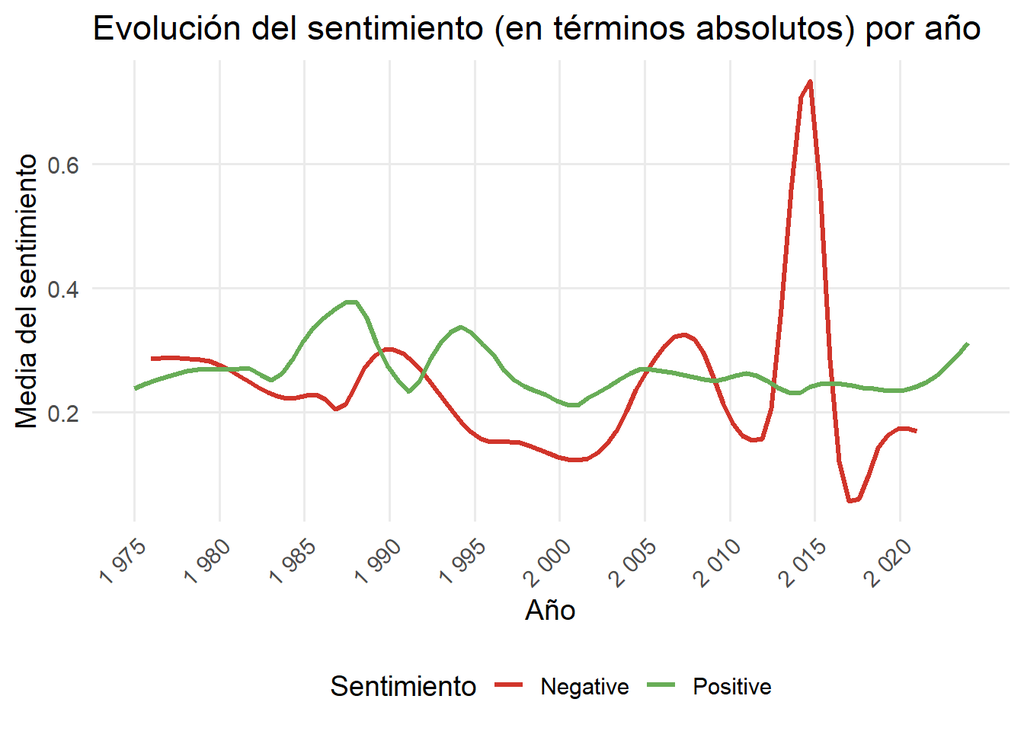

## 2.2. Paquete syuzhet

El segundo método que se utiliza para realizar análisis de sentimientos emplea el paquete “syuzhet”, que se basa en el léxico NRC. Este léxico clasifica palabras en categorías emocionales como joy, sadness, positive y negative, permitiendo obtener una medida directa de la carga emocional de cada palabra dentro de un texto. A diferencia de sentimentr, que tiene en cuenta modificadores contextuales, syuzhet se centra en la presencia y frecuencia de palabras asociadas a cada sentimiento.

```r
top_100_syuzhet <- top_100_lyrics %>% select(-html) %>%  mutate(joy = NA, sadness = NA, negative = NA, positive = NA)

for (i in 1:nrow(top_100_syuzhet)){

  oraciones_vector <- top_100_lyrics %>%
    mutate(id = row_number()) %>%
    filter(id == i) %>%
    pull(lyrics) %>%
    str_split(pattern = "\n")

  sentimientos_df <- get_nrc_sentiment(oraciones_vector[[1]], lang="english")

  sentimientos_df_summary <- summary(sentimientos_df)

  top_100_syuzhet$joy[i] <- mean(sentimientos_df$joy)
  top_100_syuzhet$sadness[i] <- mean(sentimientos_df$sadness)
  top_100_syuzhet$negative[i] <- mean(sentimientos_df$negative)
  top_100_syuzhet$positive[i] <- mean(sentimientos_df$positive)

}
```

Se vuelve a comprobar si las canciones han sido correctamente evaluadas. Por un lado, se observa que la canción más positiva es “Happy” de Pharrell Williams. Esta tiene mucho más sentido que la del método anterior.

```r
top_100_syuzhet %>% arrange(-positive) %>% slice(1) %>% select(-lyrics)
```

```
                      song      joy    sadness   negative positive
1 Happy, Pharrell Williams 1.072464 0.04347826 0.07246377 1.173913
```

Por otro lado, la canción más negativa es “Crank That (Soulja Boy)” de Soulja Boy Tell’em. Esta ya no tiene tanto sentido, ya que no suele considerarse una canción especialmente negativa. En este caso se puede estar dando porque repite constantemente la palabra “crank”, que a pesar de que se diga en el sentido de “girar las manos”, se interpreta como la acepción de “persona irritable”.

```r
top_100_syuzhet %>% arrange(-negative) %>% slice(1) %>% select(-lyrics)
```

```
                                         song       joy    sadness negative
1 Crank That (Soulja Boy), Soulja Boy Tell'em 0.1428571 0.01904762 1.133333
  positive
1 0.152381
```

Otra desventaja de utilizar los diccionarios en este contexto es que no incluyen las formas de las palabras más informales. Por ejemplo, la segunda canción detectada como más negativa es “Love Machine (Part 1)” de The Miracles, cuya letra trata del amor profesado a una mujer. Esto se de da porque a pesar de tener palabras muy positivas, estas están escritas de forma más informal, como por ejemplo “huggin’” o “kissin’”, de forma que no consigue detectarlas.

```r
top_100_syuzhet %>% arrange(-negative) %>% slice(2) %>% select(-lyrics)
```

```
                                 song       joy   sadness  negative  positive
1 Love Machine (Part 1), The Miracles 0.3428571 0.2571429 0.8285714 0.4285714
```

Se grafica la evolución de las emociones positivas y negativas. Se incluyen alegría y tristeza para poder comprobar que cuando la negatividad/positividad tiende a subir, también lo hace la tristeza/alegría, como un método de medición de la robustez y consistencia de los resultados.

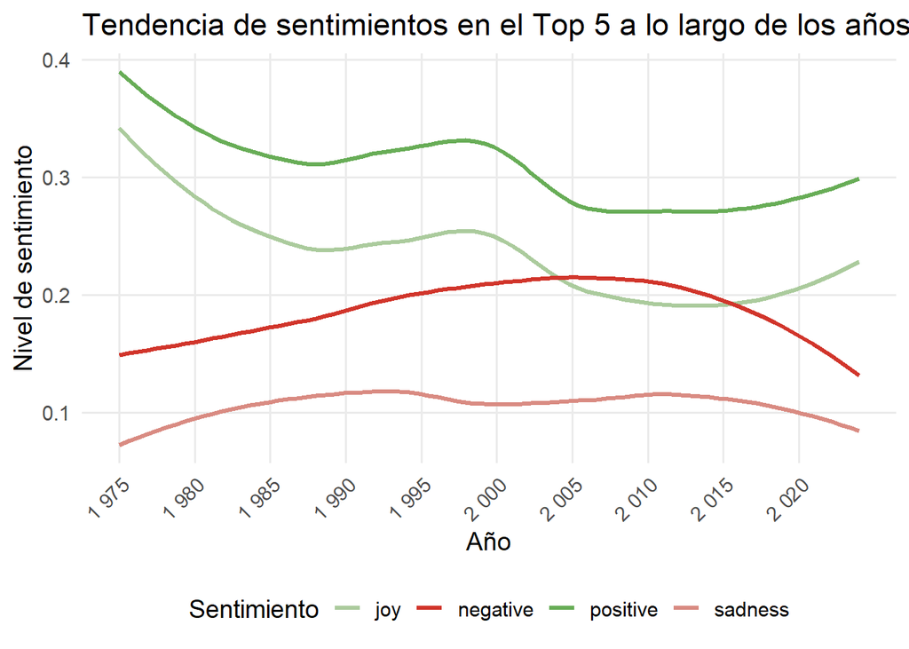

# 3. Análisis de la estructura musical

A continuación, se analiza la estructura musical de las canciones (tempo, amplitud, etc). Para ello se usan dos métodos de obtención de las métricas.

## 3.1. Paquete tuneR

Por un lado, se utiliza un método manual de cálculo de las métricas a través del paquete tuneR. Este paquete es capaz de analizar audios de tipo “wave”. Por lo tanto, lo primero que se hace es obtener los audios en formato *.wav*. Para ello, se utiliza scraping dinámico de nuevo para realizar una búsqueda automatizada de las canciones, esta vez en Youtube. De esta forma se extraen los links y se guardan en un *dataframe*.

```r
rD <- rsDriver(browser = "firefox",
               geckover = "latest",
               iedrver = NULL,
               chromever = NULL,
               phantomver = NULL,
               # extraCapabilities = eCaps,
               port = as.integer(runif(1, 4000, 8000))
)

driver <- rD[["client"]]

driver$navigate("https://www.youtube.com/watch?v=dQw4w9WgXcQ&list=RDdQw4w9WgXcQ&start_radio=1")

Sys.sleep(5)

cookie_button <- driver$findElement(
  using = "xpath",
  value = '/html/body/ytd-app/ytd-consent-bump-v2-lightbox/tp-yt-paper-dialog/div[4]/div[2]/div[6]/div[1]/ytd-button-renderer[1]'
)
cookie_button$clickElement()

Sys.sleep(0.5)

lyrics_vec <- c()

links_df <- data.frame(
  song = character(),
  link = character(),
  stringsAsFactors = FALSE
)
```

Los links extraídos se pueden entonces pasar a la web “wav.ninja”, que permite convertir links de Youtube a archivos de tipo wave. A partir de ahora solo se utilizan los últimos 5 años, de 2020 a 2024 para facilitar el proceso de descarga, que es muy pesado.

Primero se comprueban que los links sean los correctos y se corrige manualmente el número 24, que es la canción “Flowers” de Miley Cyrus y no se había guardado correctamente.

Con los links limpios, se procede a la obtención de los audios. Pero hay un detalle esencial a tener en cuenta en esta web, y es que cuando se realiza una descarga la pantalla se queda cargando, de forma que el html cambia y la automatización no es tan sencilla. Ya que el tiempo de espera hasta que vuelve a la normalidad varía, se crea un bucle que ejecuta Sys.sleep(0.5) repetidamente hasta que encuentra de nuevo el nodo de *input* de los links.

```r
links_df_last <- tail(links_df, 25)

links_df_last$link[24] <- "https://youtu.be/G7KNmW9a75Y?si=kaQ7KGQ1QkurjwyJ"

links <- links_df_last$link

links_df_last$wav_file <- NA_character_

eCaps <- list(
  `moz:firefoxOptions` = list(
    prefs = list(
      "browser.download.folderList" = 2,
      "browser.download.dir" = download_dir,
      "browser.helperApps.neverAsk.saveToDisk" =
        "audio/wav, audio/x-wav, audio/wave, audio/vnd.wave, application/octet-stream",
      "pdfjs.disabled" = TRUE,
      "browser.download.manager.showWhenStarting" = FALSE
    )
  )
)

rD <- rsDriver(browser = "firefox",
               geckover = "latest",
               iedrver = NULL,
               chromever = NULL,
               phantomver = NULL,
               # extraCapabilities = eCaps,
               port = as.integer(runif(1, 4000, 8000))
)

driver <- rD$client

driver$navigate("https://wav.ninja/")
Sys.sleep(2)

for (i in seq_along(links)) {
  link <- links[i]

    input_box <- driver$findElement(using = "xpath",
                                  value = '/html/body/div/div/div/div[1]/div/input')
  input_box$clearElement()
  input_box$sendKeysToElement(list(link, key = "enter"))
  Sys.sleep(3)

  boton_descarga <- driver$findElement(using = "xpath",
                                       value = "/html/body/div/div/div/div[1]/div/div/div/button[1]")
  boton_descarga$clickElement()

  repeat {
    encontrado <- tryCatch({
      driver$findElement(using = "xpath",
                         value = '/html/body/div/div/div/div[1]/div/input')
      TRUE
    }, error = function(e) FALSE)

    if (encontrado) break
    Sys.sleep(0.5)
  }

  Sys.sleep(2)

  files <- list.files("C:/Users/Portatil/Downloads", pattern = "\\.wav$", full.names = TRUE)
    latest_file <- files[which.max(file.info(files)$ctime)]
    links_df_last$wav_file[i] <- basename(latest_file)
}

driver$close()
rD$server$stop()
```

A continuación se utiliza el paquete tuneR para extraer las métricas principales de cada archivo de audio: duración, amplitud media y una estimación del tempo, usando propiedades matemáticas de la señal.

- La **duración** indica el tiempo total que ocupa la canción medido en segundos. Se obtiene dividiendo el número total de muestras entre la frecuencia de muestreo, porque el audio digital es una secuencia de valores tomados a intervalos fijos en el tiempo.
- La **amplitud media** es una medida básica de la intensidad general del sonido. Se calcula como el promedio del valor absoluto de la onda.
- Para estimar el **tempo**, es decir, la velocidad rítmica de una canción, se convierte el audio a mono y se aplica una autocorrelación para buscar patrones repetitivos en la señal, y el desplazamiento (lag) en el que la autocorrelación presenta su primer pico fuerte indica la periodicidad dominante; al convertir ese periodo en segundos y luego a BPM (60 / periodo) se obtiene una aproximación del ritmo.

```r
download_dir <- normalizePath("downloads", mustWork = TRUE)

links_df_last$audio_wave <- vector("list", nrow(links_df_last))

for (i in seq_len(nrow(links_df_last))) {
  wav_name <- links_df_last$wav_file[i]
  wav_path <- file.path(download_dir, wav_name)
  links_df_last$audio_wave[[i]] <- readWave(wav_path)
}

results <- data.frame(
  song = links_df_last$song,
  duration_sec = NA,
  mean_amplitude = NA,
  tempo_estimate = NA
)

for (i in seq_len(nrow(links_df_last))) {
  wav <- links_df_last$audio_wave[[i]]
  if (!is.null(wav)) {

    duration <- length(wav@left) / wav@samp.rate

    amplitude <- mean(abs(wav@left))

    wave_mono <- if (wav@stereo) mono(wav, "both") else wav

    ac <- autoc(wave_mono, f = wave_mono@samp.rate, plot = FALSE)
    lag_peak <- which.max(ac[-1]) + 1
    tempo_sec <- lag_peak / wave_mono@samp.rate
    tempo_bpm <- 60 / tempo_sec

    results$duration_sec[i] <- duration
    results$mean_amplitude[i] <- amplitude
    results$tempo_estimate[i] <- tempo_bpm
  }
}
```

```r
results <- read.xlsx("results.xlsx")
head(results)
```

```
                              song duration_sec mean_amplitude tempo_estimate
1             Circles, Post Malone     226.3713       9537.261       135.7201
2      Blinding Lights, The Weeknd     262.5712       6066.244       117.0072
3 Someone You Loved, Lewis Capaldi     185.2952       6630.437       165.8103
4           Bad Guy, Billie Eilish     205.9842       3991.901       149.1545
5           Sucker, Jonas Brothers     199.8077       3137.604       153.7657
6      Blinding Lights, The Weeknd     262.5712       6066.244       117.0072
```

## 3.2. Método de obtención de las métricas musicales a través de Tunebat

El segundo método también utiliza scraping dinámico, pero la extracción es más sencilla. Se navega la web “tunebat.com”, que permite encontrar información relevante de miles de canciones. La información utilizada en este estudio son: el “bpm”, la “key” y un si es “explicit”

- El **BPM** indica cuántos pulsos o “golpes” rítmicos ocurren en un minuto dentro de una canción. Es básicamente lo mismo que el tempo.
- La **key** indica la tonalidad en la que está escrita la canción, qué notas suenan más naturales en la pieza.
- La etiqueta **explicit** indica si la canción contiene lenguaje fuerte, referencias sexuales, violencia o contenido inapropiado según los estándares editoriales.

```r
eCaps <- list(
  `moz:firefoxOptions` = list(
    prefs = list(
      "browser.download.folderList" = 2,
      "browser.download.dir" = download_dir,
      "browser.helperApps.neverAsk.saveToDisk" =
        "audio/wav, audio/x-wav, audio/wave, audio/vnd.wave, application/octet-stream",
      "pdfjs.disabled" = TRUE,
      "browser.download.manager.showWhenStarting" = FALSE
    )
  )
)

rD <- rsDriver(browser = "firefox",
               geckover = "latest",
               iedrver = NULL,
               chromever = NULL,
               phantomver = NULL,
               # extraCapabilities = eCaps,
               port = as.integer(runif(1, 4000, 8000))
)

driver <- rD[["client"]]

driver$navigate("https://tunebat.com/")

Sys.sleep(5)

cookie_button <- driver$findElement(
  using = "xpath",
  value = '/html/body/div[3]/div[2]/div[1]/div/div[3]/div/div/div[2]/div/button[2]/span'
)
cookie_button$clickElement()

Sys.sleep(0.5)

lyrics_vec <- c()

html_music_df <- data.frame(
  song = character(),
  bpm = character(),
  key = character(),
  explicit = character(),
  stringsAsFactors = FALSE
)

songs <- results_todo$song
songs <- tolower(gsub(",", "", songs))

for (song in songs){

  Sys.sleep(5)

  input_box <- driver$findElement(
    using = "xpath",
    value = '/html/body/div[2]/section/section/div[1]/div/div[2]/span/span/input'
  )
  input_box$clearElement()
  input_box$sendKeysToElement(list(song, key = "enter"))

  driver$executeScript("window.scrollBy(0, 500);")
  Sys.sleep(5)

  top_result <- tryCatch({
    btn <- driver$findElement(
      using = "xpath",
      value = '/html/body/div[2]/section/section/main/div/div[2]/div[2]/div[1]/a/div'
    )
    btn$clickElement()
    TRUE
  }, error = function(e) FALSE)

  if (!top_result) {
    html_music_df <- rbind(html_music_df,
                           data.frame(song = song,
                                      bpm = NA,
                                      key = NA,
                                      explicit = NA))
    next
  }

  Sys.sleep(5)

  bpm <- tryCatch({
    driver$findElement(using = "xpath",
                       value = '/html/body/div[2]/section/section/main/div/div[1]/div[2]/span/div/div[3]/div/h3'
    )$getElementText()[[1]]
  }, error = function(e) NA)

  key <- tryCatch({
    driver$findElement(using = "xpath",
                       value = '/html/body/div[2]/section/section/main/div/div[1]/div[2]/span/div/div[1]/div/h3'
    )$getElementText()[[1]]
  }, error = function(e) NA)

  explicit <- tryCatch({
    driver$findElement(using = "xpath",
                       value = '/html/body/div[2]/section/section/main/div/div[1]/div[2]/div[3]/div[2]/span/span'
    )$getElementText()[[1]]
  }, error = function(e) NA)

  html_music_df <- rbind(
    html_music_df,
    data.frame(song = song,
               bpm = bpm,
               key = key,
               explicit = explicit)
  )

}

driver$close(); rD$server$stop()
```

Se encuentran varios *NA* en la base de datos, pero, como son pocos, se corrigen de forma manual.

```r
html_music_df <- read.xlsx("html_music_df.xlsx")

html_music_df %>% filter(is.na(bpm))
```

```
                                          song bpm id  key explicit
1                   blinding lights the weeknd  NA  6 <NA>     <NA>
2            mood 24kgoldn featuring iann dior  NA  7 <NA>     <NA>
3 all i want for christmas is you mariah carey  NA 14 <NA>     <NA>
4                      good 4 u olivia rodrigo  NA 15 <NA>     <NA>
5 all i want for christmas is you mariah carey  NA 16 <NA>     <NA>
6                       as it was harry styles  NA 17 <NA>     <NA>
7       die for you the weeknd & ariana grande  NA 20 <NA>     <NA>
8                     last night morgan wallen  NA 22 <NA>     <NA>
```

```r
html_music_df <- html_music_df %>%
  mutate(bpm = as.numeric(bpm),
         id = row_number())

html_music_df %>% filter(is.na(bpm))
```

```
                                          song bpm id  key explicit
1                   blinding lights the weeknd  NA  6 <NA>     <NA>
2            mood 24kgoldn featuring iann dior  NA  7 <NA>     <NA>
3 all i want for christmas is you mariah carey  NA 14 <NA>     <NA>
4                      good 4 u olivia rodrigo  NA 15 <NA>     <NA>
5 all i want for christmas is you mariah carey  NA 16 <NA>     <NA>
6                       as it was harry styles  NA 17 <NA>     <NA>
7       die for you the weeknd & ariana grande  NA 20 <NA>     <NA>
8                     last night morgan wallen  NA 22 <NA>     <NA>
```

```r
missing_info <- data.frame(
  song = c("blinding lights the weeknd",
           "mood 24kgoldn featuring iann dior",
           "all i want for christmas is you mariah carey",
           "good 4 u olivia rodrigo",
           "all i want for christmas is you mariah carey",
           "as it was harry styles",
           "die for you the weeknd & ariana grande",
           "last night morgan wallen"),
  bpm = c(171, 91, 150, 167, 150, 174, 67, 204),
  key = c("C♯ Major", "G Minor", "G Major", "A Major",
          "G Major", "F♯ Minor", "C♯ Minor", "F♯ Major"),
  explicit = c("No", "Yes", "No", "Yes",  "No", "No", "No", "Yes"),
  id = c(6, 7, 14, 15, 16, 17, 20, 22)
)
```

Finalmente, se convierten las variables a tipo dummy para poder manejarlas en formato numérico.

```r
html_music_df_final <- html_music_df %>%
  rows_update(missing_info, by = "id") %>%
  dummy_cols(select_columns = c("key", "explicit"),
             remove_first_dummy = FALSE,
             remove_selected_columns = TRUE)
```

Para comprobar si este método y el anterior cambian mucho, se compara el bpm y el tiempo, medidas casi sinónimas.

```r
t.test(html_music_df_final$bpm, results$tempo_estimate)
```

```
    Welch Two Sample t-test

data:  html_music_df_final$bpm and results$tempo_estimate
t = -2.5352, df = 46.572, p-value = 0.01466
alternative hypothesis: true difference in means is not equal to 0
95 percent confidence interval:
 -46.259431  -5.319938
sample estimates:
mean of x mean of y
 129.7600  155.5497
```

# 4. Comparación de sentimientos y métricas musicales

Para finalizar, solo queda comparar los sentimientos y las métricas musicales en sus distintos métodos.

## 4.2 Correlación entre sentimentr y métricas musicales

Primero, se comparan las métricas musicales con los resultados obtenidos a través del paquete sentimentr. Para ello se utiliza la correlación de la media de los sentimientos con los valores de “tunebeat.com” por canción.

```r
top_100_sent_last <- top_100_sent %>% tail(25)

results_todo2 <- cbind(html_music_df_final, top_100_sent_last)

vars_cor <- results_todo2 %>%
  dplyr::select(-song, -id, -lyrics, -label)

M <- cor(vars_cor, use = "pairwise.complete.obs")

corr <- M["sent_mean", ]

corr_table <- data.frame(
  variable = names(corr),
  corr = as.numeric(corr),
  row.names = NULL
) %>%
  slice(1:18)
```

```r
corr_table %>% arrange(-corr) %>% head(5)
```

```
      variable       corr
1 key_A♭.Major 0.46205755
2  key_A Major 0.28505331
3  key_C.Major 0.27954357
4  key_G Major 0.15006984
5  explicit_No 0.03937494
```

```r
corr_table %>% arrange(corr) %>% head(5)
```

```
      variable       corr
1  key_G Minor -0.3062087
2 key_C♯.Major -0.2431449
3 key_C♯ Minor -0.2047633
4 key_C♯.Minor -0.2030648
5 key_C♯ Major -0.1832890
```

Los resultados obtenidos muestran que varias tonalidades mayores presentan una correlación positiva con el sentimiento, lo que sugiere que estas tonalidades tienden a asociarse con canciones cuyas letras son más positivas.

Esto coincide con la explicación expuesta en el artículo “*Why Do Major Keys Sound Happy*?” publicado en *Medium*: en un acorde mayor, las vibraciones guardan proporciones simples y estables, lo que nuestro cerebro interpreta como un sonido claro, equilibrado y, por tanto, más “feliz”. Por otro lado, las tonalidades menores se han correlacionado en general con los sentimientos más negativos, pues estas rompen parcialmente esa alineación armónica, generando relaciones entre notas que el oído percibe como menos consonantes y más tensas.

## 4.2 Correlación entre syuzhet y métricas musicales

Se repite el proceso con los resultados de syuzhet.

```r
top_100_syuzhet_last <- top_100_syuzhet %>% tail(25)

results_todo2 <- cbind(html_music_df_final, top_100_syuzhet_last)

vars_cor <- results_todo2 %>%
  dplyr::select(-song, -id, -lyrics)

M <- cor(vars_cor, use = "pairwise.complete.obs")

corr_negative <- M["negative", ]
corr_positive <- M["positive", ]

vars_keep <- setdiff(
  colnames(M),
  c("negative", "positive", "joy", "sadness")
)

corr_negative <- corr_negative[vars_keep]
corr_positive <- corr_positive[vars_keep]

corr_table <- data.frame(
  variable = vars_keep,
  corr_positive = as.numeric(corr_positive),
  corr_negative = as.numeric(corr_negative),
  row.names = NULL
)
```

```r
corr_table %>% arrange(-corr_positive) %>% head(5)
```

```
      variable corr_positive corr_negative
1 key_A♭.Major     0.3700220   -0.33248685
2  key_A Major     0.3169432    0.06393561
3  explicit_No     0.2345109    0.10831470
4  key_A.Major     0.1326847    0.26059927
5 key_F♯ Major     0.1160154    0.17087714
```

```r
corr_table %>% arrange(-corr_negative) %>% head(5)
```

```
      variable corr_positive corr_negative
1 key_C♯.Minor  -0.001174434     0.4229536
2  key_A.Major   0.132684737     0.2605993
3  key_G Minor  -0.014261348     0.2562028
4          bpm   0.089327302     0.2258247
5  key_E.Major   0.055208355     0.1825739
```

# 5. Futuras líneas de investigación y posibles mejoras

Este estudio resulta especialmente relevante para comprender cómo ha ido cambiando el gusto musical a lo largo de los años y cómo las emociones han influido en él (o, de manera recíproca, cómo la música guía las emociones). En el futuro, este análisis podría complementarse con bases de datos sobre emociones de la población de Estados Unidos para explorar posibles correlaciones entre las tendencias musicales y los estados emocionales de sus oyentes.

Entre las mejoras potenciales, el proceso de scraping dinámico podría optimizarse, especialmente en lo relacionado con el idioma de las canciones. Sería útil detectar automáticamente el idioma (como hace el traductor de Google) y traducirlo al inglés frase por frase, dado que cada vez es más frecuente encontrar canciones con mezcla de idiomas. A partir de esa base, sería posible realizar un modelo a gran escala y extraer conclusiones más sólidas, relevantes y representativas sobre la relación entre música y emociones.